# marcos maia - Pesquisa Google

[figure not shown]

Aproximadamente 13.900.000 resultados (0,50 segundos)

## Resultados da pesquisa

### [Marco Maia | Deputado Federal](http://www.marcomaia.com.br/)

www.**marcomaia**.com.br/

- [Em cache](http://webcache.googleusercontent.com/search?q=cache:z-jkeX_frScJ:www.marcomaia.com.br/+&cd=1&hl=pt-BR&ct=clnk&gl=br)
- Similares

*Marco Maia* apresenta Projeto de Lei que permite compartilhamento de informações de delação premiada com Comissão Parlamentar de Inquérito (CPI).

### [Marco Maia – Wikipédia, a enciclopédia livre](http://pt.wikipedia.org/wiki/Marco_Maia)

pt.wikipedia.org/wiki/**Marco**_**Maia**

- [Em cache](http://webcache.googleusercontent.com/search?q=cache:n-CVbTgsmJ8J:pt.wikipedia.org/wiki/Marco_Maia+&cd=2&hl=pt-BR&ct=clnk&gl=br)
- Similares

*Marco* Aurelio Spall *Maia* (Canoas, 27 de dezembro de 1965) é um torneiro mecânico, metalúrgico e político do Brasil nascido no Rio Grande do Sul.

Biografia - [Deputado federal](http://pt.wikipedia.org/wiki/Marco_Maia#Deputado_federal) - [Referências](http://pt.wikipedia.org/wiki/Marco_Maia#Refer.C3.AAncias) - [Ligações externas](http://pt.wikipedia.org/wiki/Marco_Maia#Liga.C3.A7.C3.B5es_externas)

### [Marco Maia | Facebook](https://pt-br.facebook.com/depmarcomaia)

https://pt-br.facebook.com/dep**marcomaia**

- [Em cache](http://webcache.googleusercontent.com/search?q=cache:VZ4AQTMyfK0J:https://pt-br.facebook.com/depmarcomaia+&cd=3&hl=pt-BR&ct=clnk&gl=br)
- Similares

*Marco Maia*. 16.485 curtidas · 1.002 falando sobre isso. Deputado Federal pelo PT/RS, está em seu quarto mandato. Foi eleito presidente da Câmara para o...

### [Marco Maia | Augusto Nunes - VEJA.com](http://veja.abril.com.br/blog/augusto-nunes/tag/marco-maia/)

veja.abril.com.br/blog/augusto-nunes/tag/**marco**-**maia**/

- [Em cache](http://webcache.googleusercontent.com/search?q=cache:iCZxmqfR1TQJ:veja.abril.com.br/blog/augusto-nunes/tag/marco-maia/+&cd=4&hl=pt-BR&ct=clnk&gl=br)
- Similares

14 de dez de 2014 - *Marco Maia*, deputado federal do PT gaúcho escalado para disfarçar-se .... O calendário de *Marco Maia* terminou com uma ação importante: a ...

### [Marco Maia 1314 - Eleições 2014](http://www.eleicoes2014.com.br/marco-maia/)

www.eleicoes2014.com.br/**marco**-**maia**/

- [Em cache](http://webcache.googleusercontent.com/search?q=cache:Y6IQyMG5QUoJ:www.eleicoes2014.com.br/marco-maia/+&cd=5&hl=pt-BR&ct=clnk&gl=br)

*Marco Maia* 1314 é candidato ao cargo de Deputado Federal pelo Rio Grande do Sul pelo PT nas Eleições 2014. Natural de RS - Canoas, *Marco Maia* tem 49 ...

### [Marcos Maia 13400 - Eleições 2014](http://www.eleicoes2014.com.br/marcos-maia/)

www.eleicoes2014.com.br/**marcos**-**maia**/

- [Em cache](http://webcache.googleusercontent.com/search?q=cache:kZoM4Slr-R8J:www.eleicoes2014.com.br/marcos-maia/+&cd=6&hl=pt-BR&ct=clnk&gl=br)

*Marcos Maia* 13400 é candidato ao cargo de Deputado Estadual de Minas Gerais pelo PT nas Eleições 2014. Natural de MG - Montes Claros, *Marcos Maia* tem ...

### [Deputado MARCO MAIA - Câmara dos Deputados](http://www.camara.leg.br/internet/deputado/Dep_Detalhe.asp?id=5830634)

www.camara.leg.br/internet/deputado/Dep_Detalhe.asp?id=5830634

- [Em cache](http://webcache.googleusercontent.com/search?q=cache:lWtIaWV3Dn4J:www.camara.leg.br/internet/deputado/Dep_Detalhe.asp%3Fid%3D5830634+&cd=7&hl=pt-BR&ct=clnk&gl=br)

Informações do Deputado. Foto do Deputado *MARCO MAIA*. Nome civil: MARCO AURÉLIO SPALL MAIA; Aniversário: 27 / 12; Partido/UF: PT / RS / Titular ...

### [G1 - Marco Maia retira pré-candidatura à presidência da ...](http://g1.globo.com/politica/noticia/2014/11/marco-maia-retira-pre-candidatura-presidencia-da-camara.html)

g1.globo.com/.../**marco**-**maia**-retira-pre-candidatura-presidencia-da-cama...

- [Em cache](http://webcache.googleusercontent.com/search?q=cache:uQJIS9MflckJ:g1.globo.com/politica/noticia/2014/11/marco-maia-retira-pre-candidatura-presidencia-da-camara.html+&cd=8&hl=pt-BR&ct=clnk&gl=br)

13 de nov de 2014 - O deputado federal *Marco Maia* (PT-RS) informou nesta quinta-feira (13) que retira a sua pré-candidatura à presidência da Câmara dos ...

### [Marco Maia | Fotógrafo](http://www.marcomaia.fot.br/)

www.**marcomaia**.fot.br/

- [Em cache](http://webcache.googleusercontent.com/search?q=cache:J1fjEOLsdyoJ:www.marcomaia.fot.br/+&cd=9&hl=pt-BR&ct=clnk&gl=br)
- Similares

The personal portfolio site of *Marco Maia*. ... Alfradique para GoWhere'Rio 2011 Editorial. FOLLOW ON Bēhance. All works © *Marco Maia* 2012. All rights reserved.

### [Marco Maia (@DepMarcoMaia) | Twitter](https://twitter.com/depmarcomaia)

https://twitter.com/dep**marcomaia**

- [Em cache](http://webcache.googleusercontent.com/search?q=cache:yNAmikixjQEJ:https://twitter.com/depmarcomaia+&cd=10&hl=pt-BR&ct=clnk&gl=br)

The latest Tweets from *Marco Maia* (@DepMarcoMaia). Twitter atualizado pelo Deputado Federal *Marco Maia* (PT/RS). Quando for alimentado pela sua Ass.

### Pesquisas relacionadas a marcos maia

marcos maia **show**

marcos maia **fotografia**

marcos maia **junior**

**dr** marcos maia

**dj** marcos maia

**deputado** marcos maia

marcos maia **facebook**

marcos maia **humorista**

[output not shown]

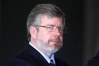

         Mais imagens
   2. Marco Maia

      Ex-Presidente da Câmara dos Deputados do Brasil
   3. Marco Aurelio Spall Maia é um torneiro mecânico, metalúrgico e político do Brasil nascido no Rio Grande do Sul. Foi presidente da Câmara dos Deputados. [Wikipédia](http://pt.wikipedia.org/wiki/Marco_Maia)
   5. Nascimento: 27 de dezembro de 1965 (49 anos), Canoas, Rio Grande do Sul
   6. Partido: Partido dos Trabalhadores
   7. Cargo anterior: Presidente da Câmara dos Deputados do Brasil (2010–2013)
   8. Pesquisas relacionadas

      Henrique Eduardo Alves

      Maria das Graças Foster

      José Sarney

      Paulo Roberto Costa

      Inocêncio de Oliveira

- [Saiba mais](https://support.google.com/websearch?p=ws_settings_location&hl=pt)